# Project Python Foundations: FoodHub Data Analysis

### Relationship between Rating and Delivery/Preparation Times

```python
df.groupby(['rating'])['total_time'].mean()
```

| rating | total_time |
| --- | --- |
| 3 | 51.989362 |
| 4 | 51.264249 |
| 5 | 51.568027 |
| Not given | 51.531250 |

**dtype:** float64

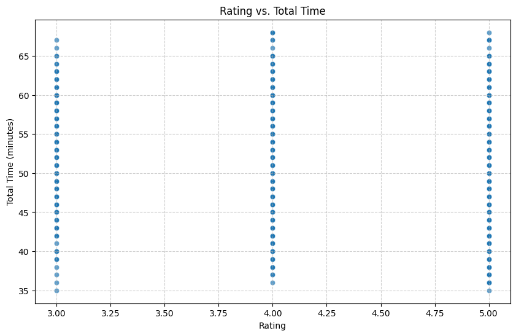

```python
rated_df = df[df['rating'] != 'Not given'].copy()
rated_df['rating'] = pd.to_numeric(rated_df['rating'])

plt.figure(figsize=(10, 6))
sns.scatterplot(data=rated_df, x='rating', y='total_time', alpha=0.7)
plt.title('Rating vs. Total Time')
plt.xlabel('Rating')
plt.ylabel('Total Time (minutes)')
plt.grid(True, linestyle='--', alpha=0.6)
plt.show()
```

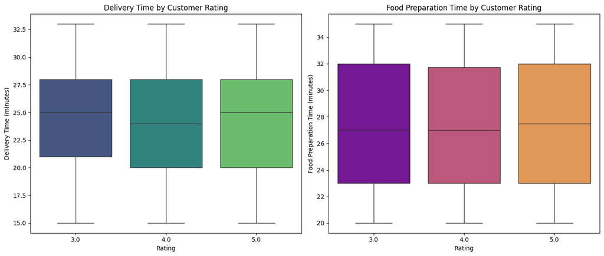

```python
rated_df = df[df['rating'] != 'Not given']
rated_df['rating'] = pd.to_numeric(rated_df['rating'])

plt.figure(figsize=(14, 6))

plt.subplot(1, 2, 1) # 1 row, 2 columns, first plot
sns.boxplot(data=rated_df, x='rating', y='delivery_time', palette='viridis')
plt.title('Delivery Time by Customer Rating')
plt.xlabel('Rating')
plt.ylabel('Delivery Time (minutes)')

plt.subplot(1, 2, 2) # 1 row, 2 columns, second plot
sns.boxplot(data=rated_df, x='rating', y='food_preparation_time', palette='plasma')
plt.title('Food Preparation Time by Customer Rating')
plt.xlabel('Rating')
plt.ylabel('Food Preparation Time (minutes)')

plt.tight_layout()
plt.show()
```

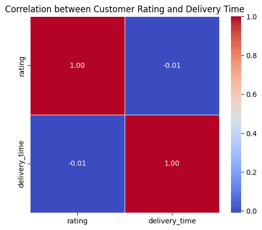

```python
correlation_matrix_rating_delivery = rated_df[['rating', 'delivery_time']].corr()

plt.figure(figsize=(6, 5))
sns.heatmap(correlation_matrix_rating_delivery, annot=True, cmap='coolwarm', fmt=".2f", linewidths=.5)
plt.title('Correlation between Customer Rating and Delivery Time')
plt.show()
```

#### Observations:

- There is not a significant relationship between customer rating and delivery time.
- The distributions have a lot of overlap in delivery time distributions across rating categories.

### **Question 13:** The company wants to provide a promotional offer in the advertisement of the restaurants. The condition to get the offer is that the restaurants must have a rating count of more than 50 and the average rating should be greater than 4. Find the restaurants fulfilling the criteria to get the promotional offer. [3 marks]

```python
rated_restaurants = df[df['rating'] != 'Not given'].copy()
rated_restaurants['rating'] = pd.to_numeric(rated_restaurants['rating'])

restaurant_ratings = rated_restaurants.groupby('restaurant_name')['rating'].agg(
    rating_count='count',
    average_rating='mean'
).reset_index()

promotional_restaurants = restaurant_ratings[
    (restaurant_ratings['rating_count'] > 50) &
    (restaurant_ratings['average_rating'] > 4)
].copy()

promotional_restaurants['average_rating'] = promotional_restaurants['average_rating'].round(2)

promotional_restaurants
```

|  | restaurant_name | rating_count | average_rating |
| --- | --- | --- | --- |
| 16 | Blue Ribbon Fried Chicken | 64 | 4.33 |
| 17 | Blue Ribbon Sushi | 73 | 4.22 |
| 117 | Shake Shack | 133 | 4.28 |
| 132 | The Meatball Shop | 84 | 4.51 |

```python
rated_restaurants = df[df['rating'] != 'Not given'].copy()
rated_restaurants['rating'] = pd.to_numeric(rated_restaurants['rating'])

restaurant_ratings = rated_restaurants.groupby('restaurant_name')['rating'].agg(
    rating_count='count',
    average_rating='mean'
).reset_index()

promotional_restaurants = restaurant_ratings[
    (restaurant_ratings['rating_count'] > 50) &
    (restaurant_ratings['average_rating'] > 4)
].copy()

promotional_restaurants['average_rating'] = promotional_restaurants['average_rating'].round(2)

promotional_restaurant_names = promotional_restaurants['restaurant_name'].tolist()

# Get the cuisine types for these promotional restaurants from the original DataFrame
promotional_cuisine_types = df[df['restaurant_name'].isin(promotional_restaurant_names)][['restaurant_name', 'cuisine_type']].drop_duplicates()

print("Cuisine types for promotional restaurants:")
display(promotional_cuisine_types)
```

```
Cuisine types for promotional restaurants:
```

|  | restaurant_name | cuisine_type |
| --- | --- | --- |
| 3 | Blue Ribbon Fried Chicken | American |
| 6 | The Meatball Shop | Italian |
| 15 | Shake Shack | American |
| 19 | Blue Ribbon Sushi | Japanese |
| 123 | The Meatball Shop | American |

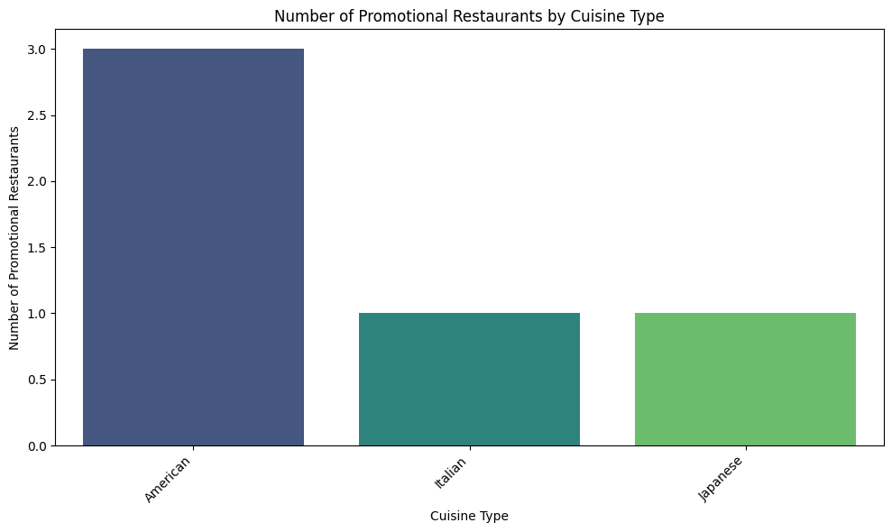

```python
cuisine_counts = promotional_cuisine_types['cuisine_type'].value_counts().reset_index()
cuisine_counts.columns = ['cuisine_type', 'num_restaurants']

plt.figure(figsize=(10, 6))
sns.barplot(x='cuisine_type', y='num_restaurants', data=cuisine_counts, palette='viridis', hue='cuisine_type', legend=False)
plt.title('Number of Promotional Restaurants by Cuisine Type')
plt.xlabel('Cuisine Type')
plt.ylabel('Number of Promotional Restaurants')
plt.xticks(rotation=45, ha='right')
plt.tight_layout()
plt.show()
```

### **Question 14:** The company charges the restaurant 25% on the orders having cost greater than 20 dollars and 15% on the orders having cost greater than 5 dollars. Find the net revenue generated by the company across all orders. [3 marks]

```python
def calculate_revenue(cost):
    if cost > 20:
        return cost * 0.25
    elif cost > 5:
        return cost * 0.15
    else:
        return 0

df['revenue'] = df['cost_of_the_order'].apply(calculate_revenue)

net_revenue = df['revenue'].sum()

print(f"Net revenue generated: ${net_revenue:.2f}")
```

```
Net revenue generated: $6166.30
```

```python
df[['cost_of_the_order', 'revenue']]
```

|  | cost_of_the_order | revenue |
| --- | --- | --- |
| 0 | 30.75 | 7.6875 |
| 1 | 12.08 | 1.8120 |
| 2 | 12.23 | 1.8345 |
| 3 | 29.20 | 7.3000 |
| 4 | 11.59 | 1.7385 |
| ... | ... | ... |
| 1894 | 12.18 | 1.8270 |
| 1895 | 25.22 | 6.3050 |
| 1896 | 12.18 | 1.8270 |
| 1897 | 19.45 | 2.9175 |
| 1898 | NaN | 0.0000 |

1899 rows × 2 columns

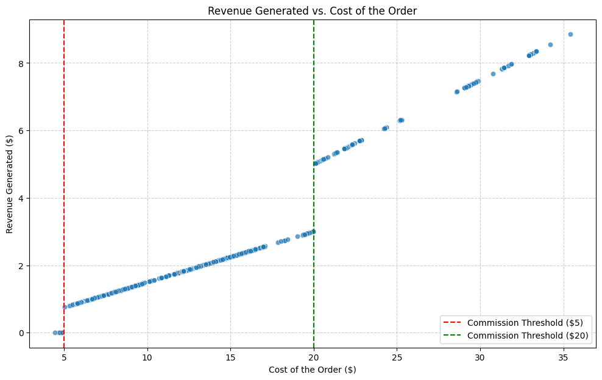

```python
def calculate_revenue(cost):
    if cost > 20:
        return cost * 0.25
    elif cost > 5:
        return cost * 0.15
    else:
        return 0

df['revenue'] = df['cost_of_the_order'].apply(calculate_revenue)

plt.figure(figsize=(12, 7))
sns.scatterplot(data=df, x='cost_of_the_order', y='revenue', alpha=0.7)
plt.title('Revenue Generated vs. Cost of the Order')
plt.xlabel('Cost of the Order ($)')
plt.ylabel('Revenue Generated ($)')
plt.grid(True, linestyle='--', alpha=0.6)
plt.axvline(x=5, color='r', linestyle='--', label='Commission Threshold ($5)')
plt.axvline(x=20, color='g', linestyle='--', label='Commission Threshold ($20)')
plt.legend()
plt.show()
```

Observation:

- The orders that generate the highest revenue are ones that cost more than $20.
- Orders costing $5 or less do not generate revenue for the company.
- The net revenue is $6,166.30
- The revenue generated from each order increases as the cost of the order increases, especially for orders above $20.
- The dataset contains 1,898 orders, so the $6,166.30 represents the combined commission earned across the entire dataset.

### **Question 15:** The company wants to analyze the total time required to deliver the food. What percentage of orders take more than 60 minutes to get delivered from the time the order is placed? (The food has to be prepared and then delivered.) [2 marks]

```python
percentage_over_60 = (df['total_time'] > 60).mean() * 100

print(f"Percentage of orders taking more than 60 minutes: {percentage_over_60:.2f}%")
```

```
Percentage of orders taking more than 60 minutes: 10.53%
```

Observations:

- 10.54% of orders take longer than 60 minutes to fulfill from the time it is ordered to the time it is delivered.
- A majority of orders take less than 60 minutes to fulfill.
- Although most orders are completed within an hour, a noticeable amountof orders take longer than 60 minutes.
- Longer wait times could impact customer satisfaction.

### **Question 16:**

The company wants to analyze the delivery time of the orders on weekdays and weekends. How does the mean delivery time vary during weekdays and weekends? [2 marks]

```python
df['day_type'] = df['day_of_the_week'].apply(
    lambda x: 'Weekend' if x == 'Weekend' else 'Weekday'
)

df.groupby('day_type')['delivery_time'].agg(
    ['mean', 'median', 'min', 'max']
)
```

| day_type | mean | median | min | max |
| --- | --- | --- | --- | --- |
| Weekday | 28.340037 | 28.0 | 24.0 | 33.0 |
| Weekend | 22.470022 | 22.0 | 15.0 | 30.0 |

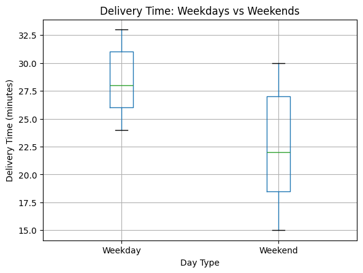

```python
import matplotlib.pyplot as plt

df.boxplot(column='delivery_time', by='day_type')

plt.xlabel('Day Type')
plt.ylabel('Delivery Time (minutes)')
plt.title('Delivery Time: Weekdays vs Weekends')
plt.suptitle('')
plt.show()
```

```python
from scipy.stats import ttest_ind

weekday = df[df['day_of_the_week'] == 'Weekday']['delivery_time']
weekend = df[df['day_of_the_week'] == 'Weekend']['delivery_time']

t_stat, p_value = ttest_ind(weekday, weekend, equal_var=False)

print("T-statistic:", t_stat)
print("P-value:", p_value)
```

```
T-statistic: 33.262190207973624
P-value: 2.5737146093950945e-184
```

#### Observations:

- During the weekday, it typically takes longer for delivery.
- There is a bigger difference between the wait times for delivery on the weekends.
- Orders take almost 6 minutes longer to deliver on weekdays than on weekends.
- Overall, delivery times are faster on weekends than on weekdays.
- Mean delivery time on weekdays is 28 minutes and on weekends it is 22 minutes.
- The minimum and maximum time for delivery is more consistent than the minimum and maximum time for delivery on the weekends.
- The fastest delivery occurs on weekends (15 minutes), which is 9 minutes faster than the fastest weekday delivery.

### Conclusion and Recommendations for question 16

- Investigate why weekday deliveries take longer than weekend deliveries.
- FoodHub might want to increase the number of delivery drivers on weekdays.
- FoodHub could focus on improving restaurant preparation and delivery coordination during weekdays.
- FoodHub should monitor weekday and weekend delivery times to determine whether operational changes that are made are improving performance.

### Recommendations:

- FoodHub could offer customers loyalty points or a small discount on their next order in exchange for rating their orders a certain number of times. This would encourage more customers to provide feedback, help gather information to enhance satisfaction, while also encouraging repeat purchases.
- FoodHub should use demand forecasting to determine times where delivery will be most popular and provide more delivery personnel during that time and provide incentives for delivery personnel to work during those times.
- FoodHub should use the popular cuisine (American food, Japanese Food, Italian Food), customer rating, and delivery performance to attract customers and feature these types of cuisines. Offer targeted promotions where discounts or deals are given from these restauarants. Along with the discounts from the restaurants, FoodHub should also provide discounts or deals by FoodHub on delivery of these types of cuisines.
- FoodHub should try to reduce the delivery times on the weekdays. This will provide a more consistent and reliable experience and therefore bring more repeat customers. In general, improving the delivery time should be a point of emphasis.
- FoodHub should monitor the restaurants with longer preparation times and help these restaurants identify ways to improve their preparation time.